# dsc520-week02-adair-d

Daniel Adair

2026-09-19

## 2.2 Exercise

Taking the provided dataset, create the following plots in R:

1. Bar graph showing product and the sum of sales for each.
2. Pie chart showing sum of sales by region.
3. Box plots for average sales by region and average quantities by region.
4. Histogram of the count of orders by product.
5. A radial plot showing total sales (for all products) by month.

### Data Processing

Tidyverse is a pre-requisite library

```r
library(tidyverse)
```

```r
sales_raw <- read_csv("~/dev/msds/dsc520/sales_data_sample.csv")
sales_cleaned <- sales_raw %>% mutate(
  Product = as.factor(Product),
  Region = as.factor(Region),
  OrderDate = as.Date(OrderDate, format = "%m/%d/%Y")
  )

sales_summarized <- sales_cleaned %>%
  group_by(Product, Region) %>%
  summarise(
    Sales_Sum = sum(TotalSales, na.rm = TRUE),
    Sales_Mean = mean(TotalSales, na.rm = TRUE),
    Order_Count = n(),
    Quantity_Sum = sum(Quantity, na.rm = TRUE),
    .groups = "drop"
    )

glimpse(sales_summarized)
```

```
## Rows: 16
## Columns: 6
## $ Product      <fct> Product_A, Product_A, Product_A, Product_A, Product_B, Pr…
## $ Region       <fct> East, North, South, West, East, North, South, West, East,…
## $ Sales_Sum    <dbl> 8464.940, 7404.195, 5692.646, 5713.517, 17291.447, 10303.…
## $ Sales_Mean   <dbl> 302.3193, 255.3171, 203.3088, 204.0542, 432.2862, 412.140…
## $ Order_Count  <int> 28, 29, 28, 28, 40, 25, 27, 28, 31, 33, 29, 39, 27, 42, 3…
## $ Quantity_Sum <dbl> 282, 280, 248, 263, 373, 243, 245, 259, 283, 324, 287, 35…
```

### 2.2.1 - Bar Chart

**Task:** Bar graph showing product and the sum of sales for each.

I’m passing **sales_summarized** through a `group_by` function to roll up sales by product. The output is passed to `barplot` for assembling the bar chart.

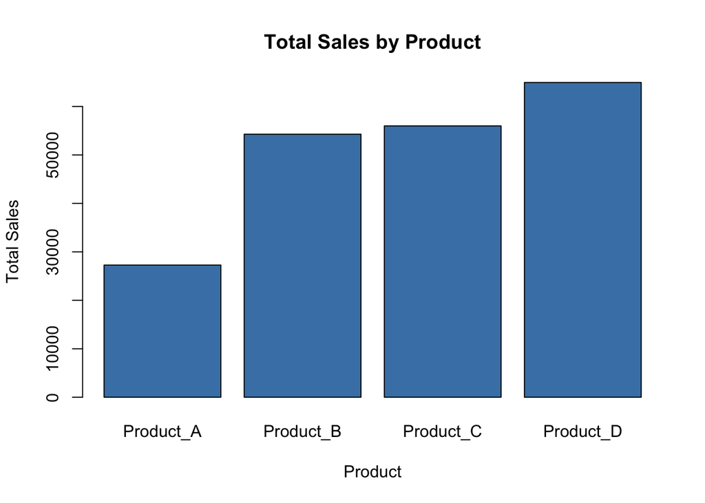

```r
product_sales <- sales_summarized %>%
  group_by(Product) %>%
  summarise(Product_Sales = sum(Sales_Sum, na.rm = TRUE), .groups = "drop")

barplot(
  height = product_sales$Product_Sales,
  names.arg = product_sales$Product,
  col = "steelblue",
  main = "Total Sales by Product",
  xlab = "Product",
  ylab = "Total Sales"
  )
```

### 2.2.2 - Pie Chart

**Task:** Pie chart showing sum of sales by region.

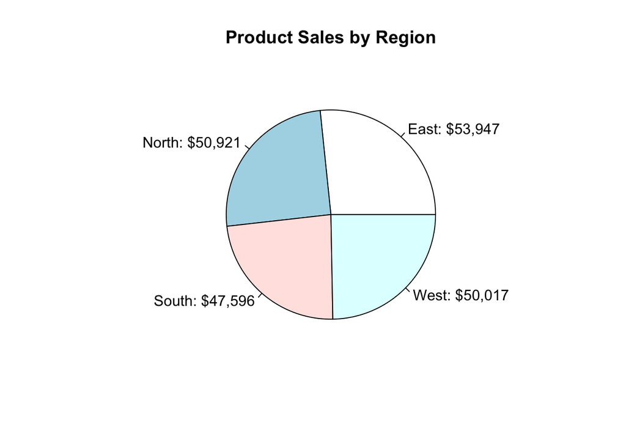

```r
# Summarizes and prepares data.
product_sales_pie <- sales_summarized %>%
  group_by(Region) %>%
  summarise(Product_Sales = sum(Sales_Sum, na.rm = TRUE), .groups = "drop")

# Pie chart of product sales by region.
pie(
  product_sales_pie$Product_Sales,
  labels = paste0(product_sales_pie$Region, ": $", scales::comma(product_sales_pie$Product_Sales)),
  main = "Product Sales by Region"
  )
```

### 2.2.3 - Box Plot Chart

**Task:** Box plots for average sales by region and average quantities by region.

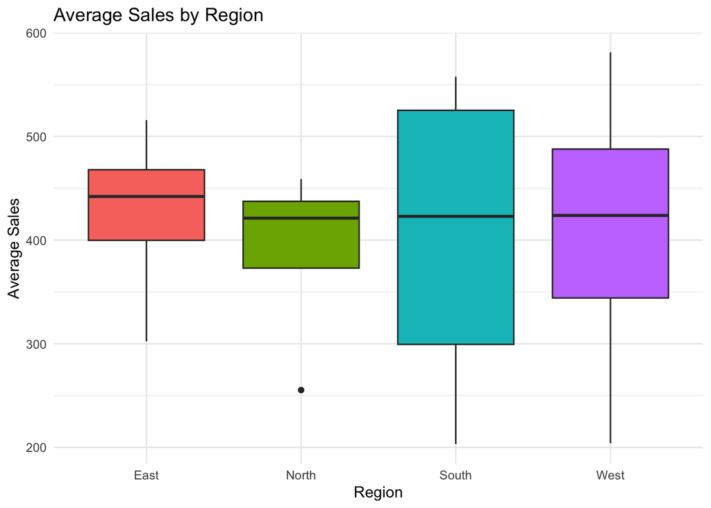

```r
# Summarizes and prepares data.
sales_summarized_box <- sales_cleaned %>%
  group_by(Product, Region) %>%
  summarise(
    Sales_Sum = sum(TotalSales, na.rm = TRUE),
    Sales_Mean = mean(TotalSales, na.rm = TRUE),
    Order_Count = n(),
    Quantity_Sum = sum(Quantity, na.rm = TRUE),
    .groups = "drop"
    )

# Box plot of average sales by region.
ggplot(sales_summarized_box, aes(x = Region, y = Sales_Mean, fill = Region)) +
    geom_boxplot(show.legend = FALSE) +
    labs(
        title = "Average Sales by Region",
        x = "Region",
        y = "Average Sales"
    ) +
    theme_minimal()
```

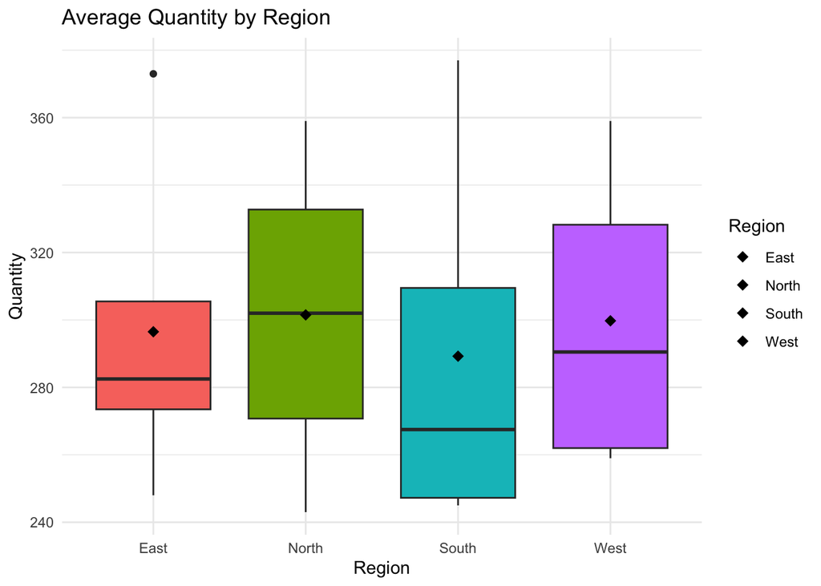

```r
# Box plot of quantities by region, with the mean shown as a point.
ggplot(sales_summarized_box, aes(x = Region, y = Quantity_Sum, fill = Region)) +
    geom_boxplot(show.legend = FALSE) +
    stat_summary(fun = mean, geom = "point", shape = 18, size = 3) +
    labs(
        title = "Average Quantity by Region",
        x = "Region",
        y = "Quantity"
    ) +
    theme_minimal()
```

```r
# boxplot(sales_summarized_box$Product_Sales, sales_summarized_box)
# ggplot(sales_summarized_box$Product_Sales, aes(Region))
```

### 2.2.4 - Histogram

**Task:** Histogram of the count of orders by product.

Note: It seems this is an invalid combination of parameters, according to the textbook’s definition of a histogram:

> The key difference between a bar plot and a histogram is that bar plots have categories on the x-axis and histograms have numerical ranges on the X-axis.

By definition, it would seem a histogram “by product” would amount to a bar chart. Since I already demonstrated the bar chart and the book emphasizes the difference between the graphs, I chose to focus on a histogram for this exercise.

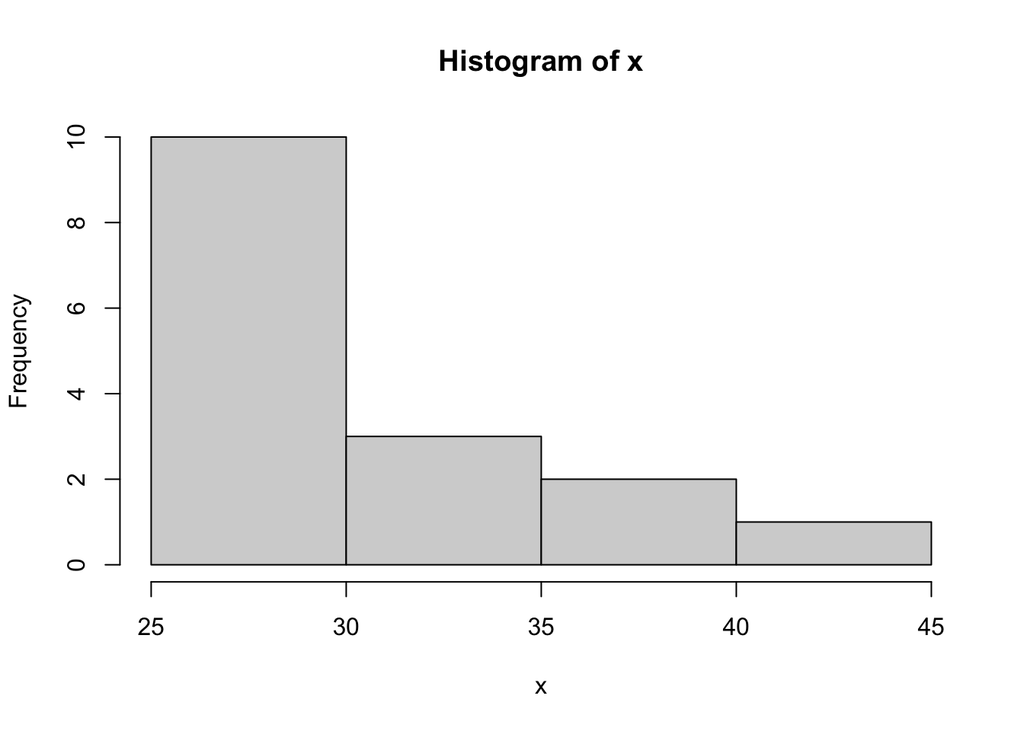

```r
x <- sales_summarized$Order_Count
hist(x)
```

### 2.2.5 - Radial Plot

**Task:** A radial plot showing total sales (for all products) by month.

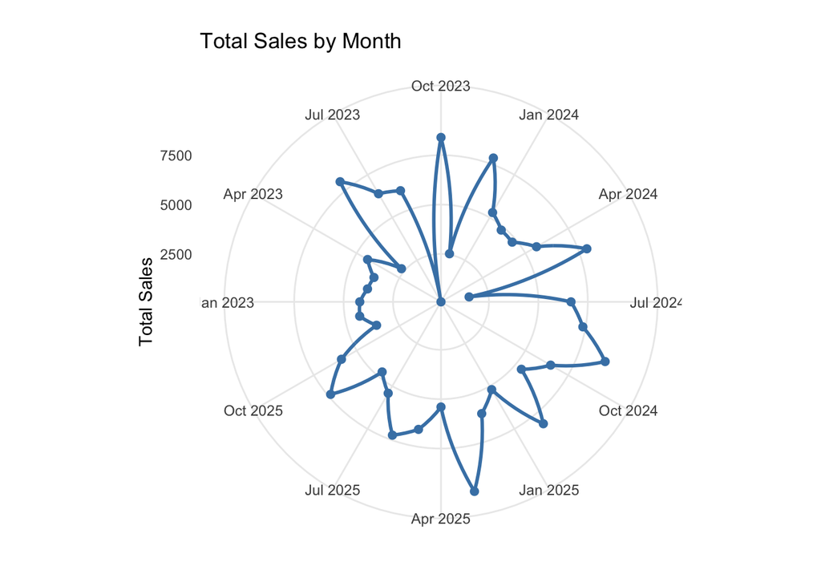

```r
# Summarize total sales across all products for each month.
monthly_sales <- sales_cleaned %>%
  mutate(Month = floor_date(OrderDate, unit = "month")) %>%
  group_by(Month) %>%
  summarise(
    Total_Sales = sum(TotalSales, na.rm = TRUE),
    .groups = "drop"
  ) %>%
  arrange(Month) %>%
  # Keep every calendar month in the sequence, even if a month has no sales.
  complete(
    Month = seq(min(Month), max(Month), by = "month"),
    fill = list(Total_Sales = 0)
  )

# Use a numeric position for each month. This avoids the factor/label mismatch
# that can occur when the first month is duplicated to close the circle.
radial_sales <- monthly_sales %>%
  mutate(
    Month_Number = row_number(),
    Month_Label = format(Month, "%b %Y")
  )

# Add a separate final x-position at the same angle as the first month so the
# line closes cleanly when it is transformed to polar coordinates.
radial_sales_closed <- radial_sales %>%
  bind_rows(
    slice(radial_sales, 1) %>%
      mutate(Month_Number = nrow(radial_sales) + 1)
  )

# Create a cleaner radial time-series plot. All monthly observations remain
# visible, but only every third month is labeled to prevent label overlap.
ggplot(radial_sales_closed, aes(x = Month_Number, y = Total_Sales, group = 1)) +
  geom_line(linewidth = 1, color = "steelblue") +
  geom_point(
    data = radial_sales,
    aes(x = Month_Number, y = Total_Sales),
    size = 2,
    color = "steelblue"
  ) +
  coord_polar(theta = "x", start = -pi / 2, direction = 1) +
  scale_x_continuous(
    breaks = seq(1, nrow(radial_sales), by = 3),
    labels = radial_sales$Month_Label[seq(1, nrow(radial_sales), by = 3)],
    limits = c(1, nrow(radial_sales) + 1),
    expand = c(0, 0)
  ) +
  scale_y_continuous(expand = c(0, 0)) +
  labs(
    title = "Total Sales by Month",
    x = NULL,
    y = "Total Sales"
  ) +
  theme_minimal() +
  theme(
    axis.text.x = element_text(size = 9),
    panel.grid.minor = element_blank(),
    plot.margin = margin(20, 30, 20, 30)
  )
```